# Reto 1: Ciudadana Basica

Author

Cadena Paul

Published

February 10, 2025

[figure not shown]

App

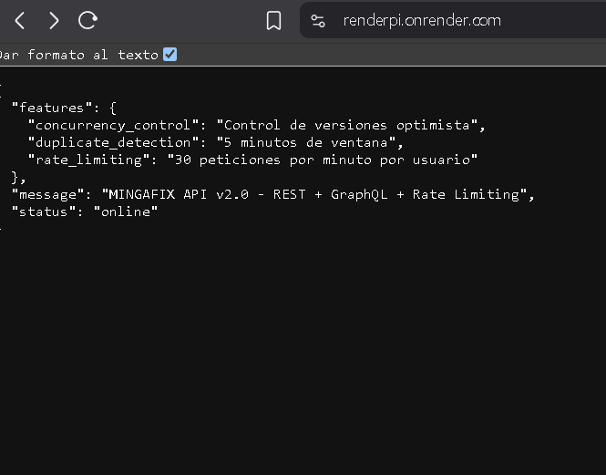

App

## Documentacion

Api implementeda a traves de: Backend: Render.com BBD y Storage: Firebase Consultas: Graphql

Qué hace esta API? Permite que ciudadanos reporten problemas en su ciudad (baches, basura, luminarias rotas, etc.) usando su celular. Los funcionarios pueden ver estos reportes y darles tratamiento.

Se puede usar Postman en este caso se usará Gitbash(simplemente usare los comandos y la comunicacion se realizará)

[figure not shown]

App

PROBAR LA API (Paso a Paso) Paso 1: Verificar que funcione bash curl https://renderpi.onrender.com

```
        Respuesta : {"status": "online", ...}
```

Crear un Reporte Para qué sirve: Un ciudadano reporta un problema (bache, basura, etc.) Endpoint: POST /reportes Qué necesitas enviar:

categoria: Tipo de problema (bache, basura, luminaria, acera_rota) lat: Latitud (ubicación en el mapa) lng: Longitud (ubicación en el mapa) descripcion: Qué está pasando usuario_id: Quién está reportando foto: Imagen del problema (opcional)

Ejemplo con foto desde tu celular: bash# Subir una foto

curl -X POST https://renderpi.onrender.com/reportes  
-F “categoria=bache”  
-F “lat=-0.8131”  
-F “lng=-77.7172”  
-F “descripcion=Bache muy grande en la avenida”  
-F “usuario_id=juan123”  
-F “foto=@/ruta/a/foto.jpg”

Ejemplo usado de codigo en video: curl -X POST https://renderpi.onrender.com/reportes  
-F “categoria=bache”  
-F “lat=-0.8131”  
-F “lng=-77.7172”  
-F “descripcion=Prueba test endpoint”  
-F “usuario_id=USER-ABC-001”  
-F “foto=@C:/Users/OneDrive/Escritorio/foto.jpg”

Límite de Reportes Regla: Solo puedes hacer 30 reportes por minuto ¿Por qué? Para evitar spam y abusos

[output not shown]

SOBRE LAS FOTOS Se guardan en Firebase Storage y esta direccion luego en la base de Datos con todos los registros de reportes

### Github

https://github.com/paulscc/RenderPi